# Red Wine Exploratory Data Analysis

#### Volatile acidity & quality with other properties

We are plotting volatile acidity vs qualtiy vs sulphates/ citric acid/ alcohol buckets. We are using jitter in the plot to reduce overplotting and geom_smooth to add a smoothed mean.

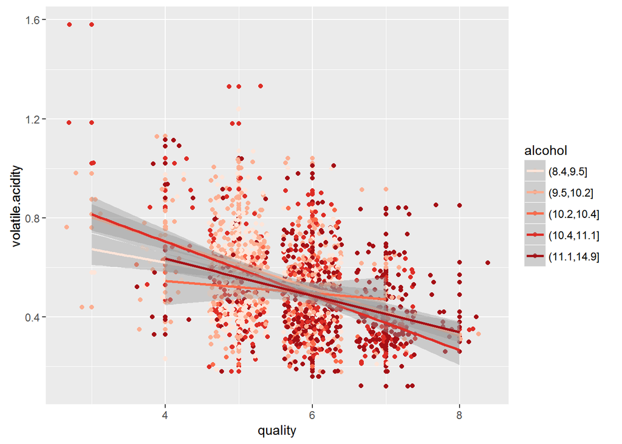

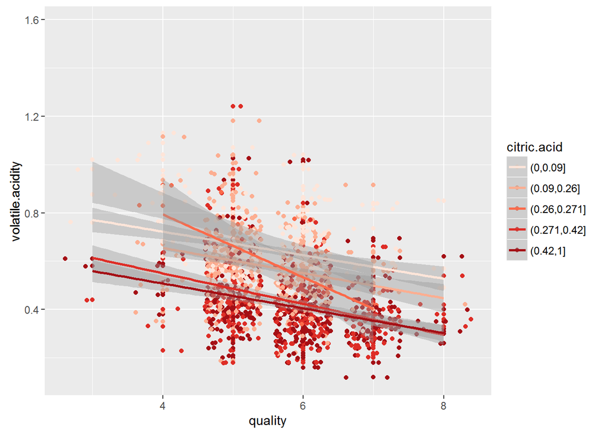

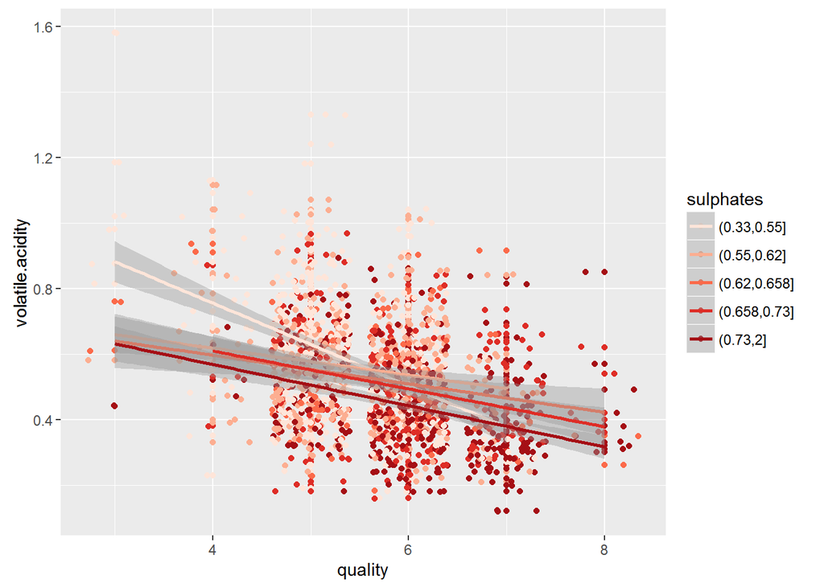

These plots show that:

1. Lower value of volatile acidity influence quality of wine.

#### Citric Acid & quality with other properties

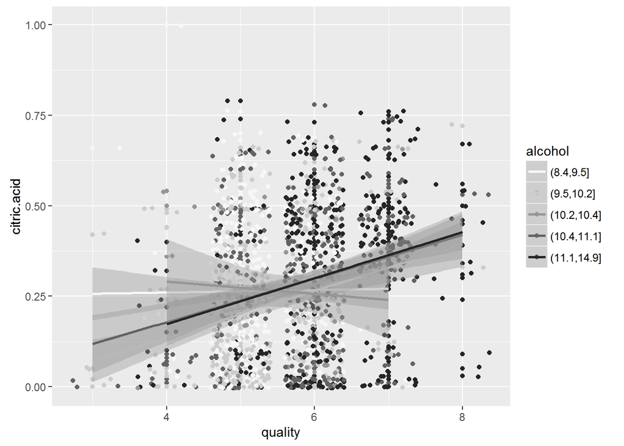

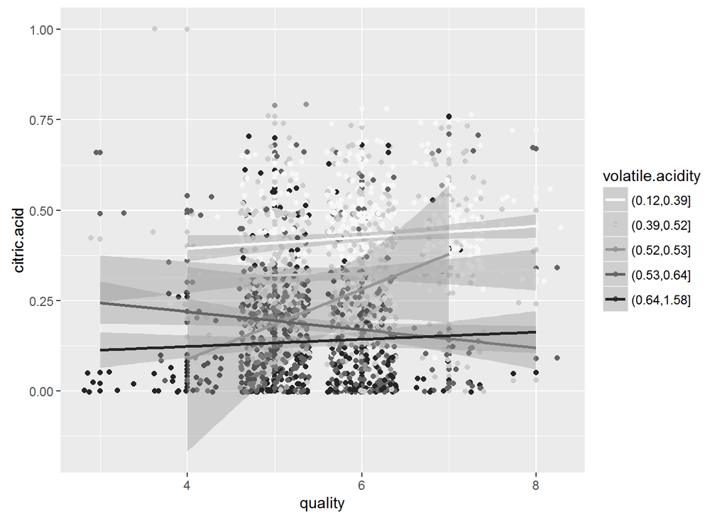

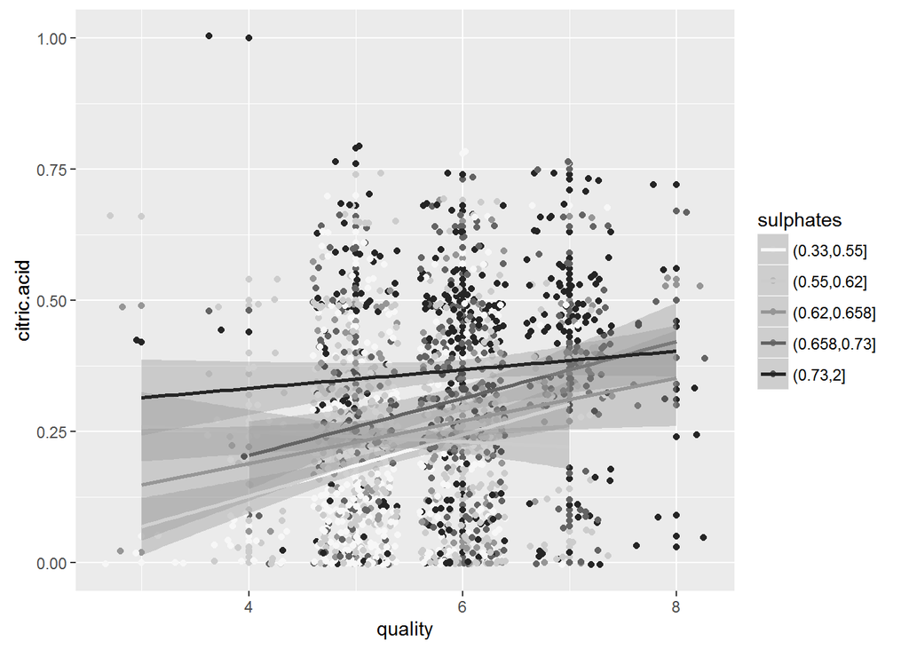

These plots shows no such good influence of citric acid with other properties on quality of wine.

#### Sulphates & quality with other properties

We are plotting sulphates vs qualtiy vs volatile acidity/ citric acid/ alcohol buckets. We are using jitter in the plot to reduce overplotting and geom_smooth to add a smoothed mean.

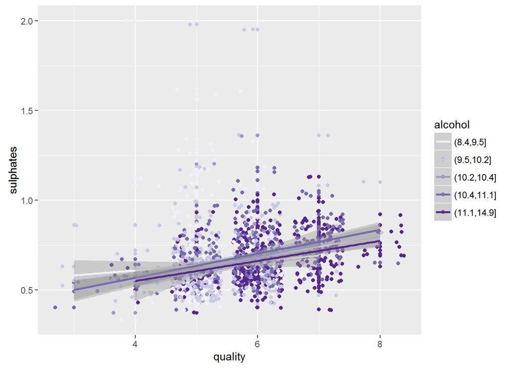

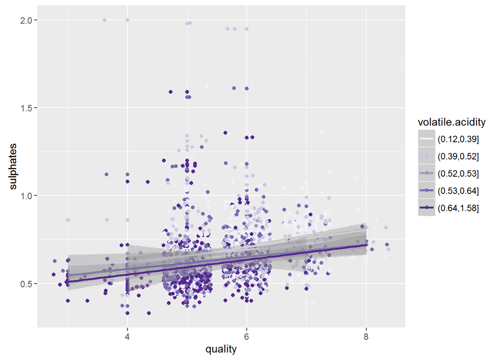

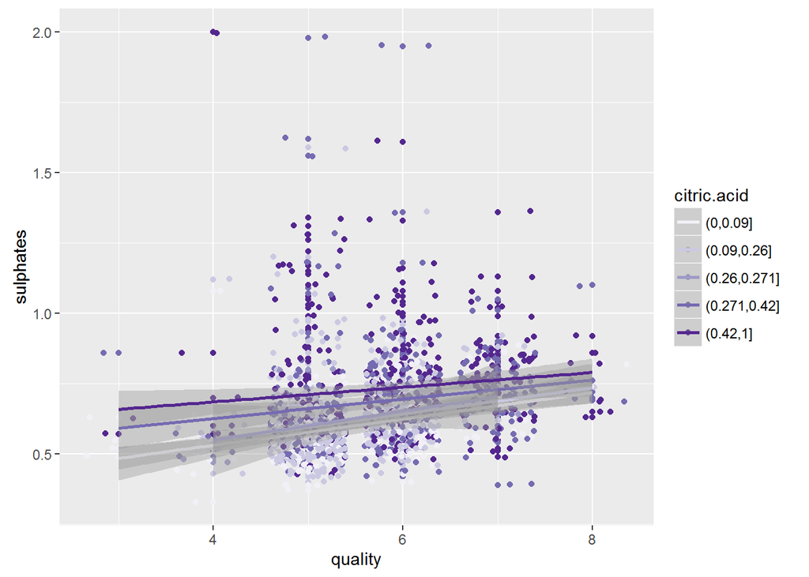

These plots show that:

1. High value of sulphates influence quality of wine.

## Multivariate Analysis

**Talk about some of the relationships you observed in this part of the investigation. Were there features that strengthened each other in terms of looking at your feature(s) of interest?**

High alcohol contribute to good quality of wine, adding sulphates or citric acid will influence the quality of wine positively.

Lower value of volatile acidity also influences the quality of wine.

**Were there any interesting or surprising interactions between features?**

Correlation plot was showing that citric acid influence the quality of wine but from these plots, we can observe that citric acid alone doen’t influence the quality. Only high alcohol & high citric acid will positively influence the quality of wine.

## Final Plots and Summary

### 1. Quality of Wines

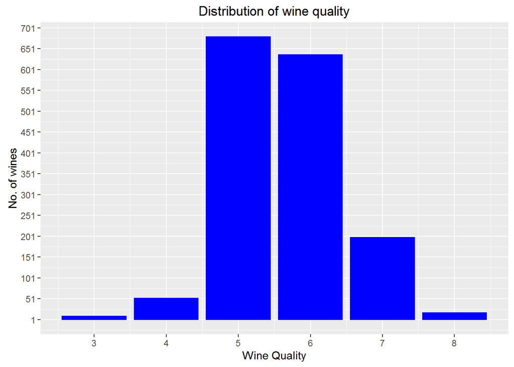

This graph explains that 82.48 % of wines in dataset are of **quality 5 & 6**. As we have to find influence of other metrics on quality of wine so this graph is very important.

### 2. Scatter Plot of Alcohol Vs Volatile Acidity vs quality

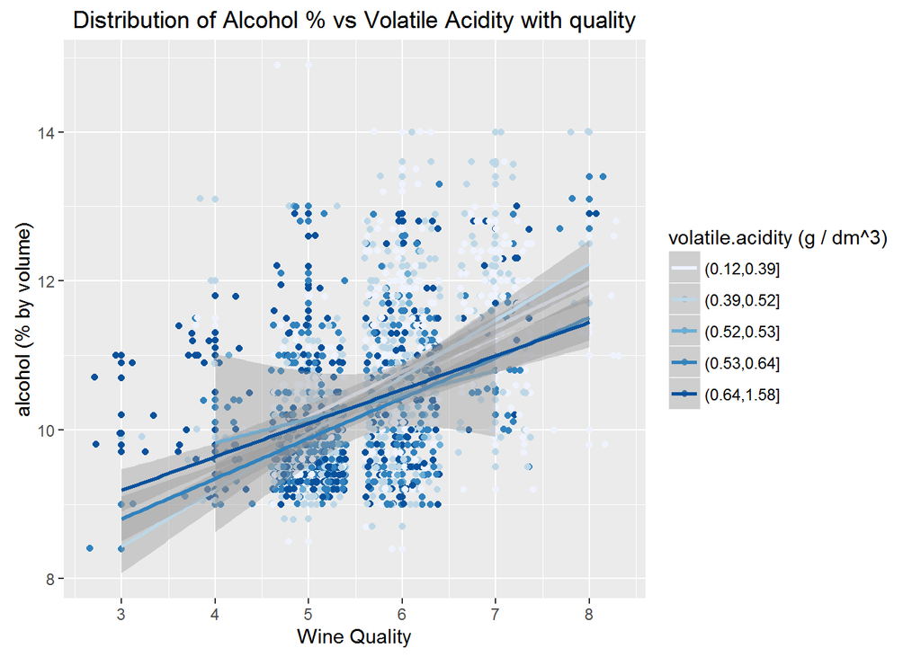

We observed that Alcohol(0.5) and volatile acidity(-0.4) are strongly correlated with quality of wine.

As they are strongly correlated, plotting scatter plot of alcohol vs volatile acidity vs quality is very important. From this scatter plot we can observe that high alcohol is positively correlated with quality of wine.

Higher value of alcohol leads to good quality of wine.

### 3. Scatter Plot of Alcohol Vs sulphates vs quality

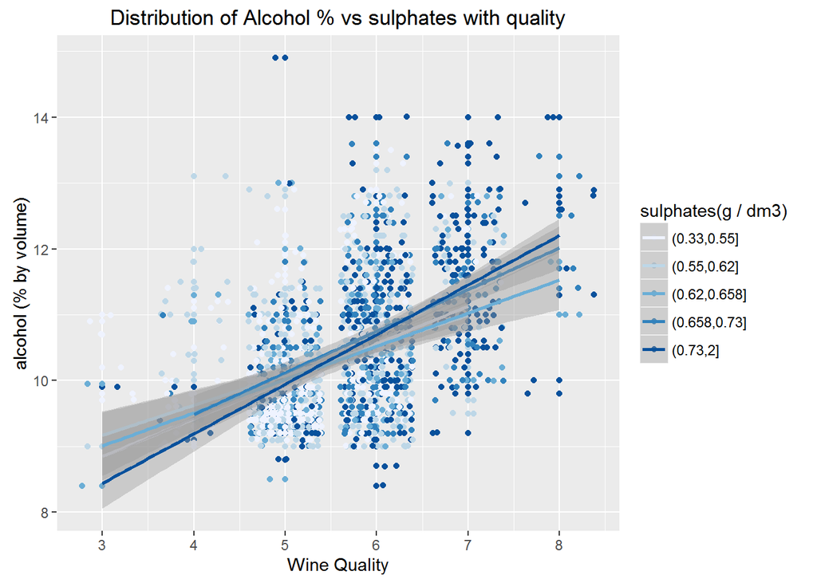

This scatter plot shows clear illustration about relationship of alcohol & sulphates with quality of wine. Its showing straight lines simlar to the lines in a graph of uniform motion. This shows that alcohol and sulphates are positively correlated.

Higher value of sulphates and alcohol leads to good quality of wine.

## Reflection

Red wine dataset contains 1599 observations with 13 variables. In this analysis, our main objective is to find out which chemical properties influence the quality of red wines.

In **Univariate analysis**, we plotted histograms of various metrics. We observed that 82% of wines are of quality 5 & quality 6. Other histograms in anlysis, didn’t gave a clear picture with which we can conclude about wines quality.

We plotted a correlation plot. It worked like magic. Using this plot, we were able analyse that alcohol, volatile.acidity, citric.acid, sulphates are correlated with quality of wine.

In **Bivariate analysis**, we plotted box-plots of correlated variables wrt quaity. These boxplots helped to analyse that good quality wines have:

1. low volatile acidity
2. high level of alcohol
3. high level of citric acid
4. high value of sulphates

In **Multivariate analysis**, we plotted scatterplots.

We again analysed the correlation plot and checked the correlation of fixed acidity with other variables, so plotted scatter plots of fixed acidity with other variables. From the graphs correlation of x-axis with y-axis is visible but their relationship with quality of wine is not visible. It didn’t gave good results.

Scatterplots of variables correlated with quality gave a good result. They helped to understand high sulphates & high alcohol , high citric acid & high alcohol, low volatile acidity, High sulphates influence quality of wine.

But scatterplot of Citric Acid with other properties didn’t gave good result.

**How could the analysis be enriched in future work (e.g. additional data and analyses)?**

The above dataset contains limited data of 1599 observations. In that dataset 82% of the wines are of quality 5 & 6. So, its not a good dataset. If we can have a dataset of 10000s+ wines with aprroximately uniform quality of wines. Then we will be able to perform a better analysis.